# Rapport ITV

## Appendix: Prediction on the overall dataset

| During | After | Age | nouveau | trop | NPS | fitted | resid |
| --- | --- | --- | --- | --- | --- | --- | --- |
| Équivalent aux tests que j’utilise actuellement | Meilleur que les tests que j’utilise actuellement | 51-60 ans | 0 | 0 | 10 | 8.10 | 1.90 |
| Équivalent aux tests que j’utilise actuellement | Équivalent aux tests que j’utilise actuellement | 61 ans et plus | 0 | 0 | 9 | 7.35 | 1.65 |
| Plutôt meilleur que les tests que j’utilise actuellement | Équivalent aux tests que j’utilise actuellement | 21-30 ans | 0 | 0 | 8 | 6.41 | 1.59 |
| Équivalent aux tests que j’utilise actuellement | Plutôt meilleur que les tests que j’utilise actuellement | 21-30 ans | 0 | 0 | 8 | 6.75 | 1.25 |
| Plutôt meilleur que les tests que j’utilise actuellement | Plutôt meilleur que les tests que j’utilise actuellement | 41-50 ans | 0 | 1 | 5 | 4.10 | 0.90 |
| Équivalent aux tests que j’utilise actuellement | Équivalent aux tests que j’utilise actuellement | 41-50 ans | 0 | 0 | 10 | 9.13 | 0.87 |
| Équivalent aux tests que j’utilise actuellement | Plutôt pire que les tests que j’utilise actuellement | 31-40 ans | 0 | 0 | 4 | 3.19 | 0.81 |
| Équivalent aux tests que j’utilise actuellement | Meilleur que les tests que j’utilise actuellement | 21-30 ans | 0 | 0 | 5 | 4.27 | 0.73 |
| Équivalent aux tests que j’utilise actuellement | Meilleur que les tests que j’utilise actuellement | 61 ans et plus | 1 | 0 | 10 | 9.35 | 0.65 |
| Équivalent aux tests que j’utilise actuellement | Meilleur que les tests que j’utilise actuellement | 41-50 ans | 0 | 0 | 9 | 8.44 | 0.56 |
| Équivalent aux tests que j’utilise actuellement | Plutôt pire que les tests que j’utilise actuellement | 21-30 ans | 0 | 1 | 1 | 0.62 | 0.38 |
| Équivalent aux tests que j’utilise actuellement | Plutôt meilleur que les tests que j’utilise actuellement | 31-40 ans | 0 | 0 | 5 | 4.62 | 0.38 |
| Équivalent aux tests que j’utilise actuellement | Meilleur que les tests que j’utilise actuellement | 61 ans et plus | 0 | 0 | 7 | 6.65 | 0.35 |
| Équivalent aux tests que j’utilise actuellement | Plutôt meilleur que les tests que j’utilise actuellement | <20 ans | 0 | 0 | 3 | 3.00 | 0.00 |
| Plutôt pire que les tests que j’utilise actuellement | Plutôt meilleur que les tests que j’utilise actuellement | 21-30 ans | 1 | 0 | 7 | 7.00 | 0.00 |
| Meilleur que les tests que j’utilise actuellement | Plutôt meilleur que les tests que j’utilise actuellement | 51-60 ans | 0 | 0 | 10 | 10.00 | 0.00 |
| Meilleur que les tests que j’utilise actuellement | Équivalent aux tests que j’utilise actuellement | 21-30 ans | 0 | 0 | 2 | 2.00 | 0.00 |
| Plutôt meilleur que les tests que j’utilise actuellement | Plutôt meilleur que les tests que j’utilise actuellement | 51-60 ans | 0 | 0 | 2 | 2.00 | 0.00 |
| Équivalent aux tests que j’utilise actuellement | Pire que les tests que j’utilise actuellement | 51-60 ans | 0 | 0 | 5 | 5.00 | 0.00 |
| Plutôt meilleur que les tests que j’utilise actuellement | Plutôt meilleur que les tests que j’utilise actuellement | 41-50 ans | 0 | 1 | 4 | 4.10 | -0.10 |
| Équivalent aux tests que j’utilise actuellement | Meilleur que les tests que j’utilise actuellement | 51-60 ans | 0 | 0 | 8 | 8.10 | -0.10 |
| Plutôt meilleur que les tests que j’utilise actuellement | Plutôt meilleur que les tests que j’utilise actuellement | 21-30 ans | 0 | 0 | 8 | 8.20 | -0.20 |
| Plutôt meilleur que les tests que j’utilise actuellement | Plutôt meilleur que les tests que j’utilise actuellement | 21-30 ans | 0 | 0 | 8 | 8.20 | -0.20 |
| Plutôt meilleur que les tests que j’utilise actuellement | Plutôt meilleur que les tests que j’utilise actuellement | 21-30 ans | 0 | 1 | 3 | 3.49 | -0.49 |
| Équivalent aux tests que j’utilise actuellement | Équivalent aux tests que j’utilise actuellement | 21-30 ans | 1 | 0 | 7 | 7.65 | -0.65 |
| Plutôt meilleur que les tests que j’utilise actuellement | Équivalent aux tests que j’utilise actuellement | 21-30 ans | 0 | 1 | 1 | 1.70 | -0.70 |
| Équivalent aux tests que j’utilise actuellement | Plutôt meilleur que les tests que j’utilise actuellement | 21-30 ans | 0 | 0 | 6 | 6.75 | -0.75 |
| Plutôt meilleur que les tests que j’utilise actuellement | Plutôt meilleur que les tests que j’utilise actuellement | 41-50 ans | 0 | 0 | 8 | 8.81 | -0.81 |
| Équivalent aux tests que j’utilise actuellement | Équivalent aux tests que j’utilise actuellement | 21-30 ans | 0 | 0 | 4 | 4.96 | -0.96 |
| Équivalent aux tests que j’utilise actuellement | Plutôt pire que les tests que j’utilise actuellement | 31-40 ans | 0 | 0 | 2 | 3.19 | -1.19 |
| Équivalent aux tests que j’utilise actuellement | Meilleur que les tests que j’utilise actuellement | 41-50 ans | 0 | 0 | 7 | 8.44 | -1.44 |
| Équivalent aux tests que j’utilise actuellement | Équivalent aux tests que j’utilise actuellement | 51-60 ans | 0 | 0 | 7 | 8.80 | -1.80 |
| Équivalent aux tests que j’utilise actuellement | Meilleur que les tests que j’utilise actuellement | 61 ans et plus | 0 | 0 | 4 | 6.65 | -2.65 |

## Appendix: Testing the linear regression model

Results from training the model with 70% of the data and testing it with the remaining data.  
We perform 100 iterations with different seeds, and we show here the results.

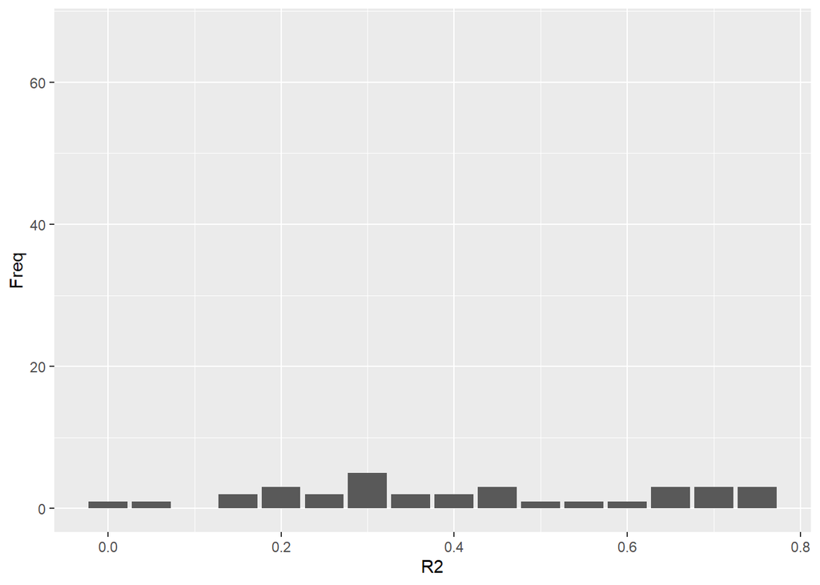

After 100 iterations and 67 missing values, the median value for the R2 is 0.38.

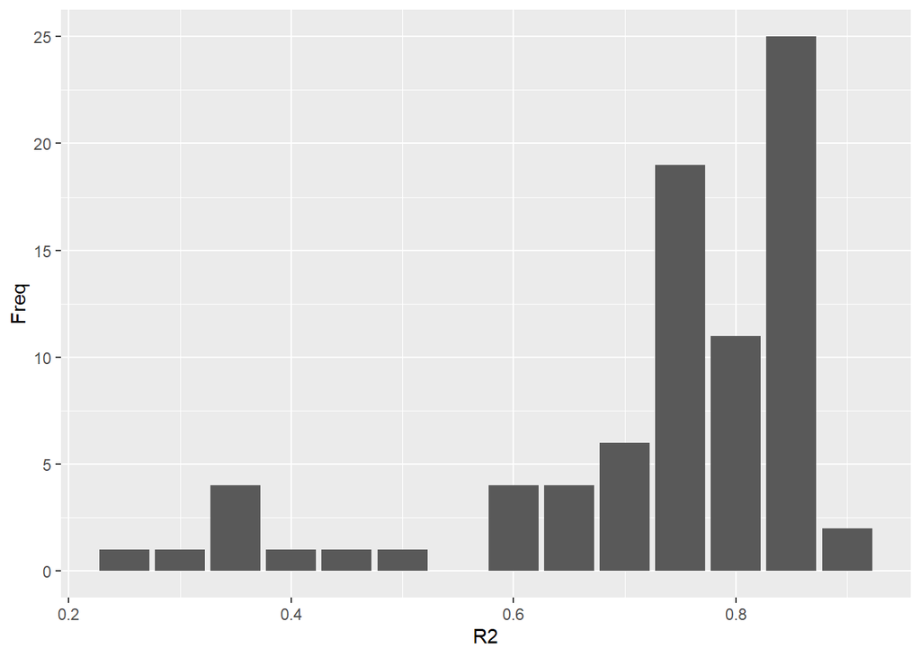

After 100 iterations and 20 missing values, the median value for the R2 is 0.77.